# Blocked Practice Stimuli Analysis

2026-04-14

## Import & Organize Stimuli Sheet

```r
# Import
stimuli <- suppressMessages(
  read_csv("../stimuli/670Corpus.csv"))

library(dplyr)

# Clean + sort
stimuli_clean <- stimuli %>%
  select(Target, CategoryName) %>%
  arrange(CategoryName) %>%
  filter(!is.na(CategoryName), CategoryName != "NA")

# Split by category
stimuli_split <- split(stimuli_clean, stimuli_clean$CategoryName)

# Create main output directory
dir.create("stimuli_by_category", showWarnings = FALSE)

# Write files
#for (cat in names(stimuli_split)) {

  #dir.create(file.path("stimuli_by_category", cat), showWarnings = FALSE)

  #df_cat <- stimuli_split[[cat]]

  # remove category column
  #words <- df_cat$Target

  # ---- ADD CATEGORY NAME AS FIRST ROW ----
  #output_vec <- c(cat, words)

  # write to CSV as single-column file
  #write.table(
  #  data.frame(output_vec),
   # file = file.path("stimuli_by_category", cat, "vocab.csv"),
  #  row.names = FALSE,
  #  col.names = FALSE,
  #  quote = FALSE
 # )
#}
```

First, I imported the stimuli excel sheet and split the stimuli into vocabulary lists for each category. I then extracted 512-dimensional word embeddings from *Universal Sentence Encoder* for each word in each category, including the category label itself. This is a type of distributional semantic model, which represents text as numerical vectors such that semantically similar inputs are located near one another in a high-dimensional space. These embeddings look like this (with 512 dimensions (rows) per embedding):

```r
mammals_embeddings<-read.csv("stimuli_by_category/Mammals/USE_embeddings.csv")
mammals_embeddings[1:6,1:6]
```

```
##        Mammals          bat        bear         bull        camel          cat
## 1 -0.048531685 -0.056882160 -0.05091261 -0.017199330  0.042625926 -0.064583290
## 2  0.041769430  0.013927644 -0.03969200  0.006989515  0.000247854 -0.003074389
## 3  0.010386131  0.027131658 -0.03813258 -0.061142400 -0.007894990  0.021574425
## 4  0.040415870  0.052750580  0.02401370 -0.003424113  0.018519280  0.036353330
## 5 -0.009592108 -0.034465607 -0.01667977 -0.072056420 -0.034709636 -0.040043560
## 6 -0.001097398 -0.009435164  0.04917246 -0.001166711 -0.029967496  0.040660914
```

The resulting lists/embeddings were then run through get_similarities.py to create semantic matrices for each category, including N x N matrices for calculating interitem similarities between all words in the list and 1 x N matrices to get similarity between all items and the category label itself. Similarity between each pair is calculated as the cosine of the angle between the two numerical vectors representing each word. For example:

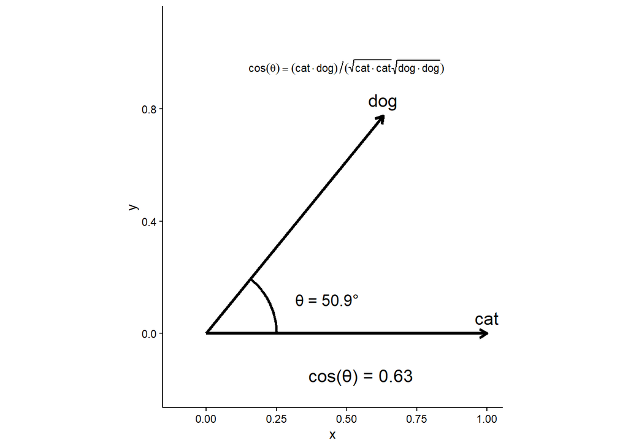

```r
# Example
cat_vec <- c(1.0, 0.0)
dog_vec <- c(0.63, sqrt(1 - 0.63^2))  # unit vector with cos(theta)=0.63

# Cosine similarity function
cos_sim <- function(a, b) {
  sum(a * b) / (sqrt(sum(a^2)) * sqrt(sum(b^2)))}

#Plot vectors
sim <- cos_sim(cat_vec, dog_vec)
angle_rad <- acos(sim)
angle_deg <- angle_rad * 180 / pi

vec_df <- data.frame(
  x = c(0, 0),
  y = c(0, 0),
  xend = c(cat_vec[1], dog_vec[1]),
  yend = c(cat_vec[2], dog_vec[2]),
  word = c("cat", "dog"))

# Arc to show the angle
theta <- seq(0, angle_rad, length.out = 100)
arc_df <- data.frame(
  x = 0.25 * cos(theta),
  y = 0.25 * sin(theta))

#plot
ggplot() +
  geom_segment(data = vec_df,
               aes(x = x, y = y, xend = xend, yend = yend),
               arrow = arrow(length = unit(0.25, "cm")),
               linewidth = 1.2) +
  geom_text(data = vec_df,
            aes(x = xend, y = yend, label = word),
            vjust = -0.7,
            size = 5) +
  geom_path(data = arc_df, aes(x = x, y = y), linewidth = 1) +
  annotate("text",
           x = 0.43, y = 0.12,
           label = paste0("θ = ", round(angle_deg, 1), "°"),
           size = 4.5) +
  annotate("text",
           x = 0.55, y = -0.15,
           label = paste0("cos(θ) = ", round(sim, 2)),
           size = 5) +
  coord_fixed(xlim = c(-0.1, 1), ylim = c(-0.2, 1.1)) +
  theme_classic()+annotate("text",
         x = 0.5, y = 0.95,
         label = "cos(theta) == (cat %.% dog) / (sqrt(cat %.% cat) * sqrt(dog %.% dog))",
         parse = TRUE,
         size = 3)
```

For example, the N x N item similarity matrix for Mammals looks like this (only a subset for illustrative purposes):

```r
mammals_ex_items<-read.csv("stimuli_by_category/Mammals/USE_semantic_matrix_items.csv")%>%rename(" "="X")
mammals_ex_items[1:6,1:6]
```

```
##               bat      bear      bull     camel       cat
## 1   bat 1.0000000 0.3939639 0.3460693 0.3486761 0.4680997
## 2  bear 0.3939639 1.0000000 0.4119342 0.2871714 0.4450067
## 3  bull 0.3460693 0.4119342 1.0000000 0.4119480 0.3461628
## 4 camel 0.3486761 0.2871714 0.4119480 1.0000000 0.3006329
## 5   cat 0.4680997 0.4450067 0.3461628 0.3006329 1.0000000
## 6   cow 0.4381917 0.4130222 0.5748645 0.3863483 0.4396570
```

While the 1 x N category label-item similarity matrix looks like this:

```r
mammals_ex_label<-read.csv("stimuli_by_category/Mammals/USE_semantic_matrix_category_label.csv")%>%rename(" "="X")
knitr::kable(mammals_ex_label)
```

|  | bat | bear | bull | camel | cat | cow | deer | dog | dolphin | elephant | fox | giraffe | goat | guinea.pigs | horse | kangaroo | lion | monkey | moose | mouse | pig | porcupine | rabbit | raccoon | seal | skunk | squirrel | tiger | walrus | … |
| --- | --- | --- | --- | --- | --- | --- | --- | --- | --- | --- | --- | --- | --- | --- | --- | --- | --- | --- | --- | --- | --- | --- | --- | --- | --- | --- | --- | --- | --- | --- |
| Mammals | 0.3738804 | 0.2464345 | 0.3030292 | 0.3525027 | 0.33389 | 0.439352 | 0.3921964 | 0.3396302 | 0.4192575 | 0.3829872 | 0.2835396 | 0.3713209 | 0.3463505 | 0.3554351 | 0.3997356 | 0.3958891 | 0.3030898 | 0.3161099 | 0.348036 | 0.3884097 | 0.2917473 | 0.3095676 | 0.3182578 | 0.3361351 | 0.3568239 | 0.2633666 | 0.3102671 | 0.2508385 | 0.4131754 | … |

These matrices were then run through a function to get average similarities for each matrix type (skipping diagonals for average interitem similarity).

## Looking At Average Similarities

First, we will calculate the average of each type of similarity for each category and combine into one data frame.

```r
#calculate average similarity (ie, how well given item fits in category) from original rating data
stimuli_avg <- stimuli %>% rename(Name=NormName,Category=CategoryName)%>%
  select(Name, Category) %>%
  filter(Category != "Uncategorized") %>%
  arrange(Category) %>%
  group_by(Category)

#import DSM derived item x label similarities for each category & combine into one df
base_dir <- "stimuli_by_category"

item_similarities_long <- list.dirs(base_dir, recursive = FALSE) %>%
  map_dfr(function(cat_path) {
    cat_name <- basename(cat_path)
    file_path <- file.path(cat_path, "USE_semantic_matrix_category_label.csv")
    if (!file.exists(file_path)) {
      message("Skipping ", cat_name)
      return(NULL)}
    # read matrix (row names = label word)
    df <- read.csv(file_path, row.names = 1, check.names = FALSE)
    df %>%
      tibble::rownames_to_column("Label_Word") %>%
      pivot_longer(
        cols = -Label_Word,
        names_to = "Item",
        values_to = "Similarity"
      ) %>%
      mutate(Category = cat_name)
  }) %>%
  select(Category, Item, Similarity) %>%filter(Category != "Uncategorized")

#import AVERAGED label x item and interitem similarities
average_similarities<-read.csv("category_average_similarity_combined.csv")%>%rename("Similarity_Type"="Matrix_Type")


#link data
average_similarities<-average_similarities%>%
  pivot_wider(
    names_from = Similarity_Type,
    values_from = Average_Similarity)%>%filter(CategoryName!="Uncategorized")
```

Now, let’s look at the average label-item and item-item similarities.

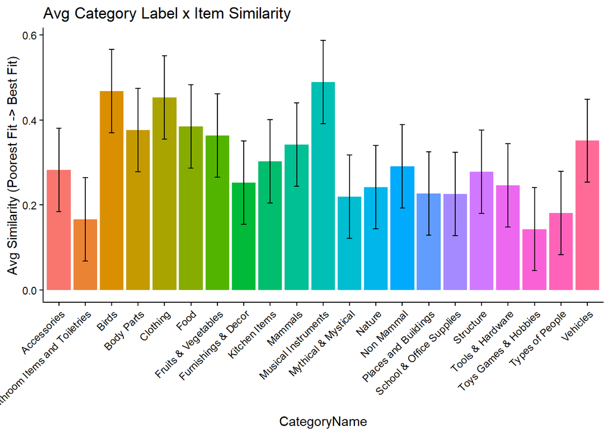

```r
#average label x item similarities (DSM derived)
avg_label<-average_similarities %>% mutate(SD_Similarity = sd(Label, na.rm = TRUE))%>% ggplot(aes(x = CategoryName, y = Label,fill=CategoryName)) +
  geom_col() +
  geom_errorbar(aes(ymin = Label - SD_Similarity,
                    ymax = Label + SD_Similarity),
                width = 0.2) +
   ylab("Avg Similarity (Poorest Fit -> Best Fit)") + ggtitle("Avg Category Label x Item Similarity")+
  theme_classic() +theme(legend.position="none")+
  theme(axis.text.x = element_text(angle = 45, hjust = 1))

#average inter-item similarity across categories
avg_interitem<-average_similarities %>% mutate(SD_Similarity = sd(Interitem, na.rm = TRUE))%>% ggplot(aes(x = CategoryName, y = Interitem,fill=CategoryName)) +
  geom_col() +
  geom_errorbar(aes(ymin = Interitem - SD_Similarity,
                    ymax = Interitem + SD_Similarity),
                width = 0.2) +
  ylab("Avg Similarity (Poorest Fit -> Best Fit)") +ggtitle("Avg Item x Item Similarity")+
  theme_classic() +theme(legend.position="none")+
  theme(axis.text.x = element_text(angle = 45, hjust = 1))


#compare distributions
avg_label
```

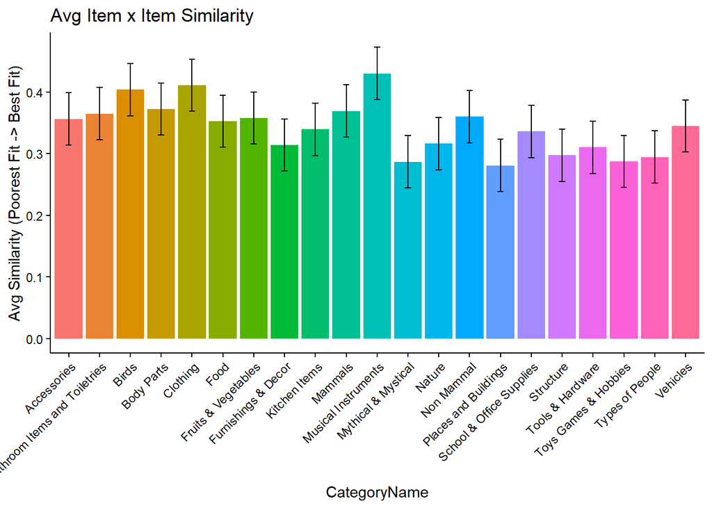

```r
avg_interitem
```

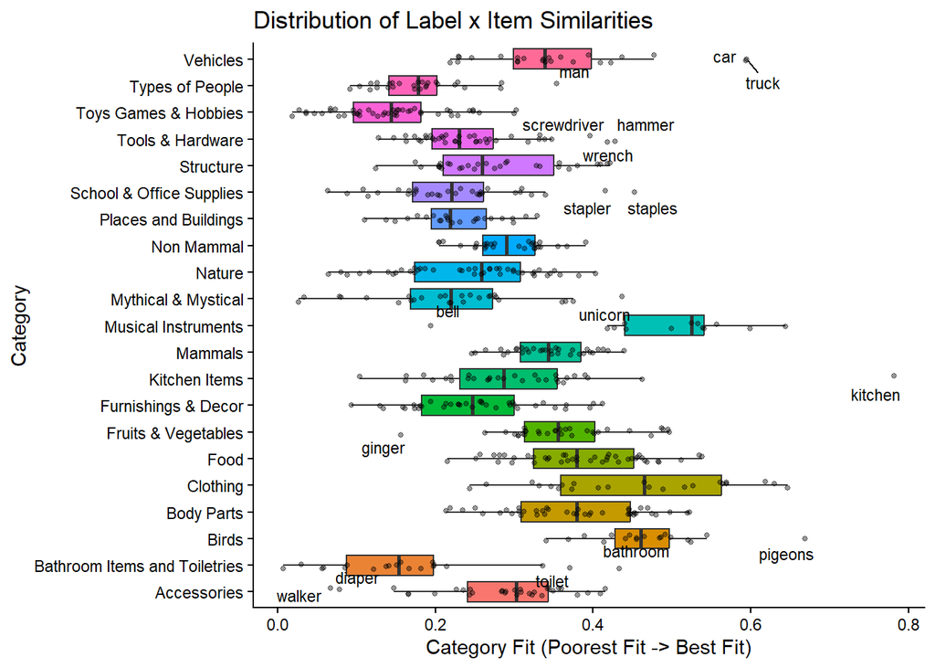

```r
#Item wise distribution of label x item similarity across categories (DSM derived)
#ID outliers
interitem_outliers <- item_similarities_long %>%
  filter(Category != "Uncategorized") %>%
  group_by(Category) %>%
  mutate(
    Q1 = quantile(`Similarity`, 0.25, na.rm = TRUE),
    Q3 = quantile(`Similarity`, 0.75, na.rm = TRUE),
    IQR = IQR(`Similarity`, na.rm = TRUE),
    lower = Q1 - 1.5 * IQR,
    upper = Q3 + 1.5 * IQR,
    is_outlier = `Similarity` < lower | `Similarity` > upper
  ) %>%
  ungroup()

#plot
itemwise_dsm_plot<-item_similarities_long %>%
  filter(!is.na(Category), Category != "NA") %>%
  ggplot(aes(x = Category, y = `Similarity`, fill = Category)) +
  geom_boxplot(outlier.shape = NA) +
  geom_jitter(width = 0.15, alpha = 0.4, size = 1) +
  coord_flip() +
  geom_text_repel(
    data = interitem_outliers %>% filter(is_outlier),
    aes(label = Item),
    size = 3,
    max.overlaps = 50
  ) +
  theme_classic() +ylab("Category Fit (Poorest Fit -> Best Fit)")+ggtitle("Distribution of Label x Item Similarities")+
  theme(legend.position = "none")

itemwise_dsm_plot
```

We can also look at the distribution of item-item similarities and identify items with weak cohesion. Below, I’ve marked (in red) the 3 items in each category with the lowest average similarity.

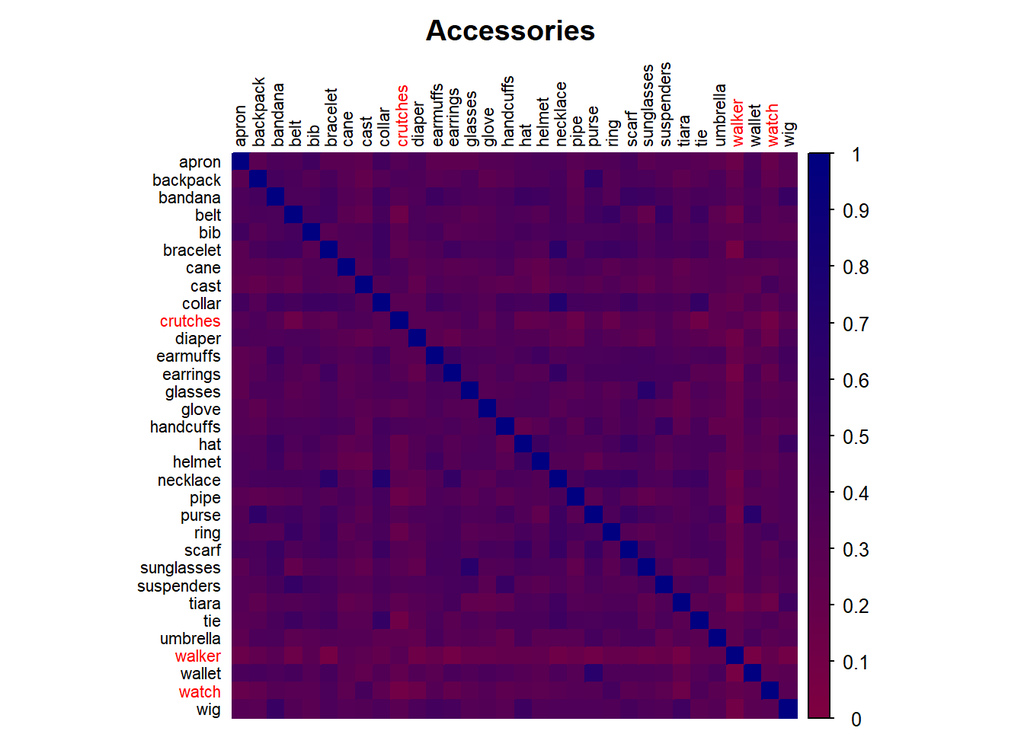

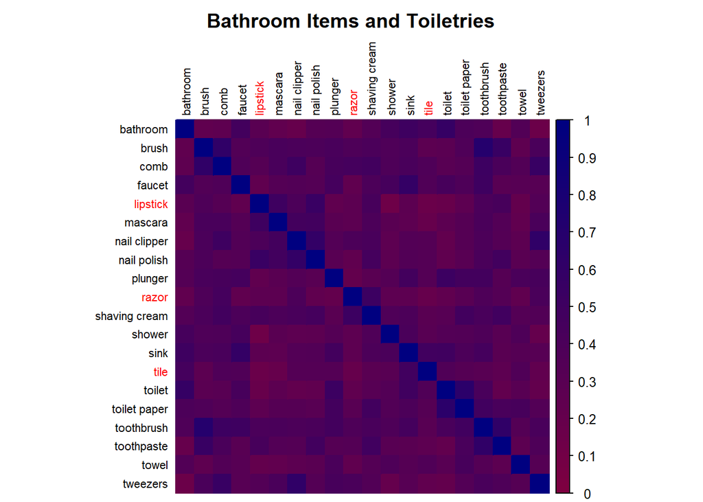

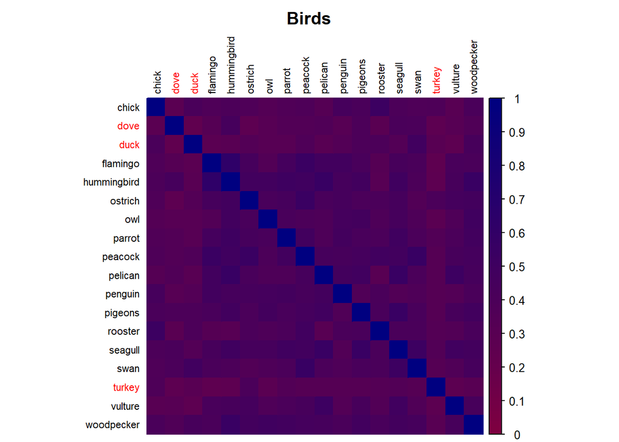

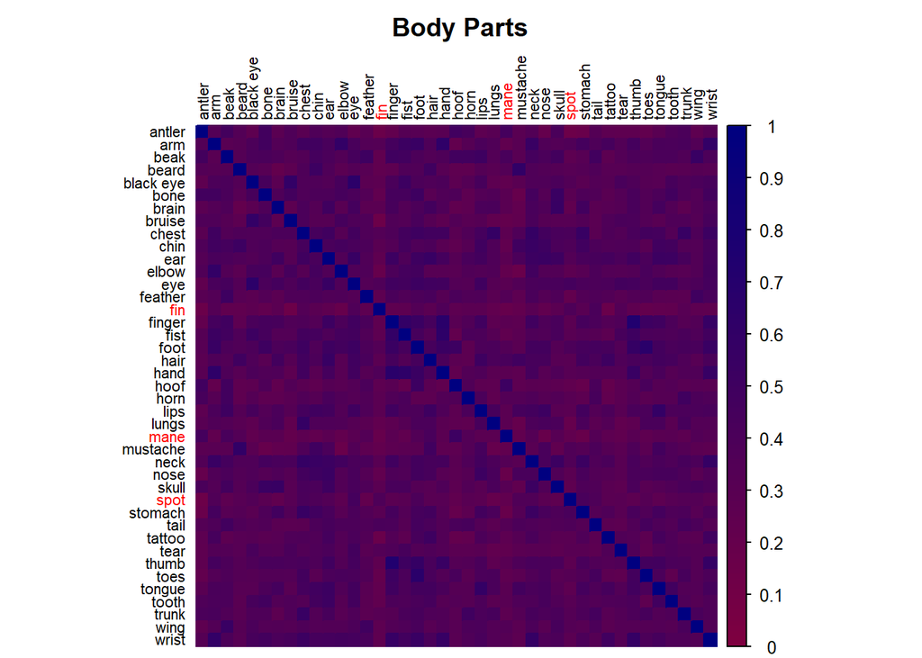

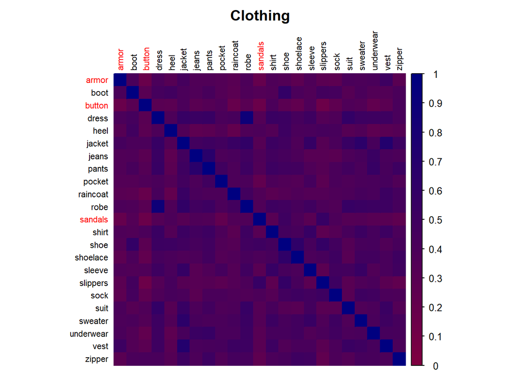

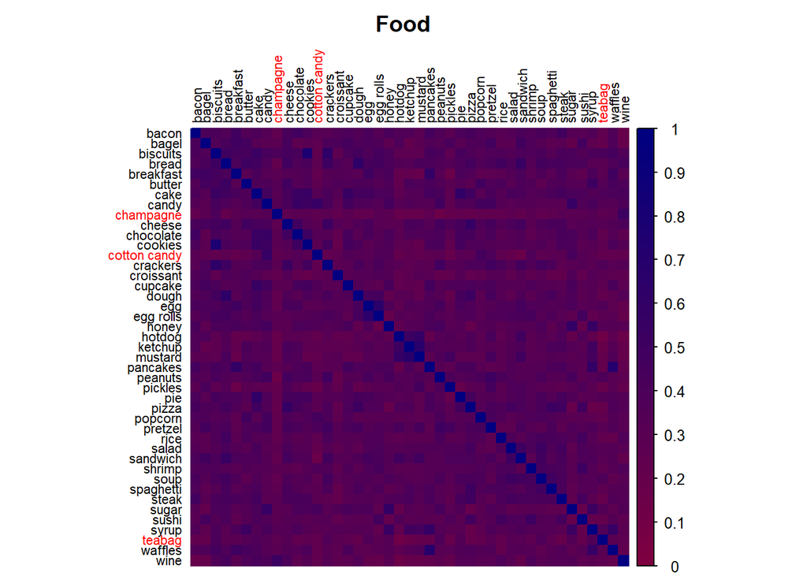

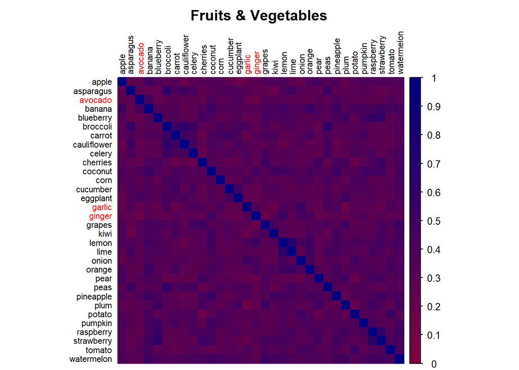

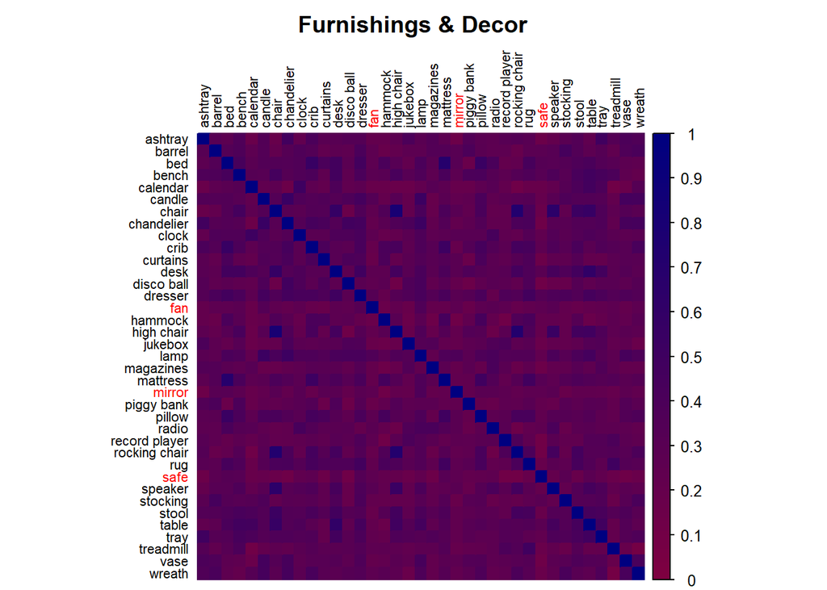

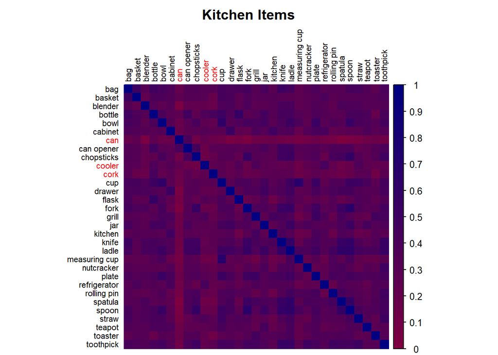

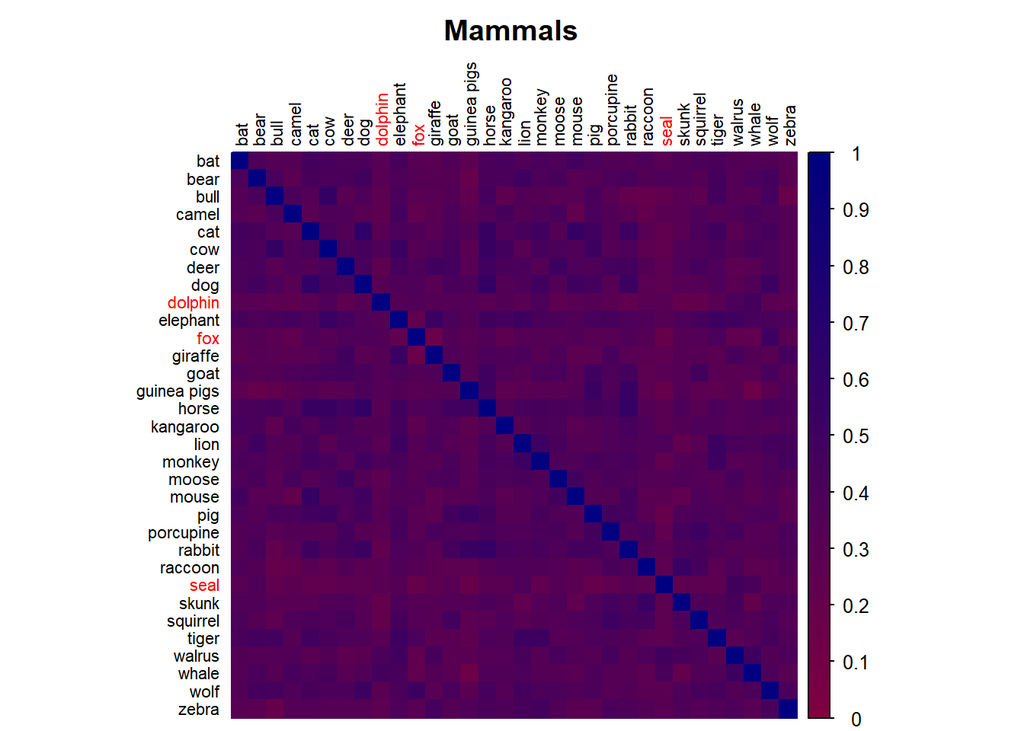

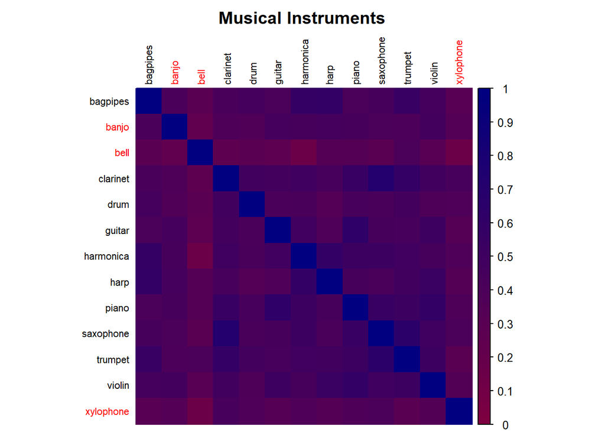

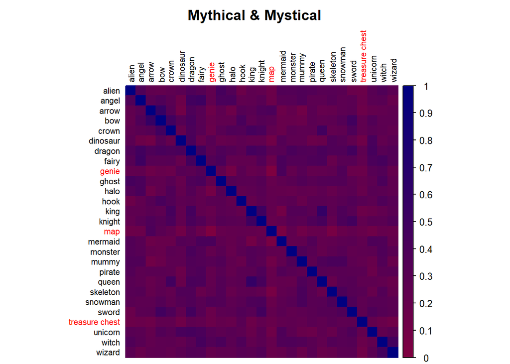

[10 more figures not shown]

```r
library(purrr)
library(corrplot)

base_dir <- "stimuli_by_category"
cat_dirs <- list.dirs(base_dir, recursive = FALSE)

# store results here
all_item_means <- data.frame()

walk(cat_dirs, function(cat_path) {
  cat_name <- basename(cat_path)
  file_path <- file.path(cat_path, "USE_semantic_matrix_items.csv")

  # read matrix
  mat <- read.csv(file_path, row.names = 1, check.names = FALSE)
  mat <- as.matrix(mat)
  mode(mat) <- "numeric"

  # compute mean similarity (exclude diagonal)
  mat_avg <- mat
  diag(mat_avg) <- NA
  item_means <- rowMeans(mat_avg, na.rm = TRUE)

  # ---- NEW: save to global dataframe ----
  df_cat <- data.frame(
    category = cat_name,
    item = names(item_means),
    CohesionScore = as.numeric(item_means),
    row.names = NULL
  )

  all_item_means <<- rbind(all_item_means, df_cat)

  # identify 3 lowest items
  lowest_items <- names(sort(item_means))[1:3]
  label_colors <- ifelse(rownames(mat) %in% lowest_items, "red", "black")

  col_fun <- colorRampPalette(c("red", "navy"))(200)

  # plot (UNCHANGED)
  corrplot(
    mat,
    method = "color",
    type = "full",
    col = col_fun,
    tl.col = label_colors,
    tl.cex = 0.7,
    title = cat_name,
    col.lim = c(0, 1),
    mar = c(0, 0, 2, 0)
  )
})
```

# Output average cohesion scores per item per category

```r
all_item_means_join<-all_item_means %>%left_join(item_similarities_long%>%rename(item=Item,category=Category,LabelCohesionScore=Similarity))%>% filter(category != "Uncategorized")
write.csv(all_item_means_join,"670_Cohesion_scores.csv")
```